# NetflixCS

```python
import numpy as np
import pandas as pd
import matplotlib.pyplot as plt
import seaborn as sns
```

```python
!wget "https://d2beiqkhq929f0.cloudfront.net/public_assets/assets/000/000/940/original/netflix.csv"
```

```
--2024-07-24 05:32:09--  https://d2beiqkhq929f0.cloudfront.net/public_assets/assets/000/000/940/original/netflix.csv
Resolving d2beiqkhq929f0.cloudfront.net (d2beiqkhq929f0.cloudfront.net)... 18.160.146.106, 18.160.146.28, 18.160.146.45, ...
Connecting to d2beiqkhq929f0.cloudfront.net (d2beiqkhq929f0.cloudfront.net)|18.160.146.106|:443... connected.
HTTP request sent, awaiting response... 200 OK
Length: 3399671 (3.2M) [text/plain]
Saving to: ‘netflix.csv’

netflix.csv         100%[===================>]   3.24M  --.-KB/s    in 0.09s

2024-07-24 05:32:09 (37.5 MB/s) - ‘netflix.csv’ saved [3399671/3399671]
```

```python
df=pd.read_csv("netflix.csv")
df
```

|  | show_id | type | title | director | cast | country | date_added | release_year | rating | duration | listed_in | description |
| --- | --- | --- | --- | --- | --- | --- | --- | --- | --- | --- | --- | --- |
| 0 | s1 | Movie | Dick Johnson Is Dead | Kirsten Johnson | NaN | United States | September 25, 2021 | 2020 | PG-13 | 90 min | Documentaries | As her father nears the end of his life, filmm... |
| 1 | s2 | TV Show | Blood & Water | NaN | Ama Qamata, Khosi Ngema, Gail Mabalane, Thaban... | South Africa | September 24, 2021 | 2021 | TV-MA | 2 Seasons | International TV Shows, TV Dramas, TV Mysteries | After crossing paths at a party, a Cape Town t... |
| 2 | s3 | TV Show | Ganglands | Julien Leclercq | Sami Bouajila, Tracy Gotoas, Samuel Jouy, Nabi... | NaN | September 24, 2021 | 2021 | TV-MA | 1 Season | Crime TV Shows, International TV Shows, TV Act... | To protect his family from a powerful drug lor... |
| 3 | s4 | TV Show | Jailbirds New Orleans | NaN | NaN | NaN | September 24, 2021 | 2021 | TV-MA | 1 Season | Docuseries, Reality TV | Feuds, flirtations and toilet talk go down amo... |
| 4 | s5 | TV Show | Kota Factory | NaN | Mayur More, Jitendra Kumar, Ranjan Raj, Alam K... | India | September 24, 2021 | 2021 | TV-MA | 2 Seasons | International TV Shows, Romantic TV Shows, TV ... | In a city of coaching centers known to train I... |
| ... | ... | ... | ... | ... | ... | ... | ... | ... | ... | ... | ... | ... |
| 8802 | s8803 | Movie | Zodiac | David Fincher | Mark Ruffalo, Jake Gyllenhaal, Robert Downey J... | United States | November 20, 2019 | 2007 | R | 158 min | Cult Movies, Dramas, Thrillers | A political cartoonist, a crime reporter and a... |
| 8803 | s8804 | TV Show | Zombie Dumb | NaN | NaN | NaN | July 1, 2019 | 2018 | TV-Y7 | 2 Seasons | Kids' TV, Korean TV Shows, TV Comedies | While living alone in a spooky town, a young g... |
| 8804 | s8805 | Movie | Zombieland | Ruben Fleischer | Jesse Eisenberg, Woody Harrelson, Emma Stone, ... | United States | November 1, 2019 | 2009 | R | 88 min | Comedies, Horror Movies | Looking to survive in a world taken over by zo... |
| 8805 | s8806 | Movie | Zoom | Peter Hewitt | Tim Allen, Courteney Cox, Chevy Chase, Kate Ma... | United States | January 11, 2020 | 2006 | PG | 88 min | Children & Family Movies, Comedies | Dragged from civilian life, a former superhero... |
| 8806 | s8807 | Movie | Zubaan | Mozez Singh | Vicky Kaushal, Sarah-Jane Dias, Raaghav Chanan... | India | March 2, 2019 | 2015 | TV-14 | 111 min | Dramas, International Movies, Music & Musicals | A scrappy but poor boy worms his way into a ty... |

8807 rows × 12 columns

```python
df.describe()
```

|  | release_year |
| --- | --- |
| count | 8807.000000 |
| mean | 2014.180198 |
| std | 8.819312 |
| min | 1925.000000 |
| 25% | 2013.000000 |
| 50% | 2017.000000 |
| 75% | 2019.000000 |
| max | 2021.000000 |

```python
df.info()
```

```
<class 'pandas.core.frame.DataFrame'>
RangeIndex: 8807 entries, 0 to 8806
Data columns (total 12 columns):
 #   Column        Non-Null Count  Dtype
---  ------        --------------  -----
 0   show_id       8807 non-null   object
 1   type          8807 non-null   object
 2   title         8807 non-null   object
 3   director      6173 non-null   object
 4   cast          7982 non-null   object
 5   country       7976 non-null   object
 6   date_added    8797 non-null   object
 7   release_year  8807 non-null   int64
 8   rating        8803 non-null   object
 9   duration      8804 non-null   object
 10  listed_in     8807 non-null   object
 11  description   8807 non-null   object
dtypes: int64(1), object(11)
memory usage: 825.8+ KB
```

```python
df.isna().sum()
```

```
show_id            0
type               0
title              0
director        2634
cast             825
country          831
date_added        10
release_year       0
rating             4
duration           3
listed_in          0
description        0
dtype: int64
```

```python
#As the Null values are very few dropping them for better analysis
df.dropna(subset= ["date_added", "rating", "duration"], inplace=True)
```

```python
df1=df.loc[:,["title","director","cast","country","listed_in"]]
df1.head()
```

|  | title | director | cast | country | listed_in |
| --- | --- | --- | --- | --- | --- |
| 0 | Dick Johnson Is Dead | Kirsten Johnson | NaN | United States | Documentaries |
| 1 | Blood & Water | NaN | Ama Qamata, Khosi Ngema, Gail Mabalane, Thaban... | South Africa | International TV Shows, TV Dramas, TV Mysteries |
| 2 | Ganglands | Julien Leclercq | Sami Bouajila, Tracy Gotoas, Samuel Jouy, Nabi... | NaN | Crime TV Shows, International TV Shows, TV Act... |
| 3 | Jailbirds New Orleans | NaN | NaN | NaN | Docuseries, Reality TV |
| 4 | Kota Factory | NaN | Mayur More, Jitendra Kumar, Ranjan Raj, Alam K... | India | International TV Shows, Romantic TV Shows, TV ... |

# **What does 'good' look like**

## **1. Find the counts of each categorical variable both using graphical and non-graphical analysis.**

### Non-Graphical analysis

```python
col=["director","cast","country","listed_in"]
for i in df1.columns:
  if i in col:
    df1[i]=df1[i].replace(", ",",")
```

```python
for i in df1.columns:
  if i in col:
    df1[i]=df1[i].str.split(",")
```

```python
df1=df1.explode("director")
df1=df1.explode("cast")
df1=df1.explode("country")
df1=df1.explode("listed_in")
```

```python
df1
```

|  | title | director | cast | country | listed_in |
| --- | --- | --- | --- | --- | --- |
| 0 | Dick Johnson Is Dead | Kirsten Johnson | NaN | United States | Documentaries |
| 1 | Blood & Water | NaN | Ama Qamata | South Africa | International TV Shows |
| 1 | Blood & Water | NaN | Ama Qamata | South Africa | TV Dramas |
| 1 | Blood & Water | NaN | Ama Qamata | South Africa | TV Mysteries |
| 1 | Blood & Water | NaN | Khosi Ngema | South Africa | International TV Shows |
| ... | ... | ... | ... | ... | ... |
| 8806 | Zubaan | Mozez Singh | Anita Shabdish | India | International Movies |
| 8806 | Zubaan | Mozez Singh | Anita Shabdish | India | Music & Musicals |
| 8806 | Zubaan | Mozez Singh | Chittaranjan Tripathy | India | Dramas |
| 8806 | Zubaan | Mozez Singh | Chittaranjan Tripathy | India | International Movies |
| 8806 | Zubaan | Mozez Singh | Chittaranjan Tripathy | India | Music & Musicals |

201837 rows × 5 columns

```python
df.drop(columns=["director","cast","country","listed_in"],inplace=True)
```

```python
df_final=df.merge(df1,on="title")
df_final.head()
```

|  | show_id | type | title | date_added | release_year | rating | duration | description | director | cast | country | listed_in |
| --- | --- | --- | --- | --- | --- | --- | --- | --- | --- | --- | --- | --- |
| 0 | s1 | Movie | Dick Johnson Is Dead | September 25, 2021 | 2020 | PG-13 | 90 min | As her father nears the end of his life, filmm... | Kirsten Johnson | NaN | United States | Documentaries |
| 1 | s2 | TV Show | Blood & Water | September 24, 2021 | 2021 | TV-MA | 2 Seasons | After crossing paths at a party, a Cape Town t... | NaN | Ama Qamata | South Africa | International TV Shows |
| 2 | s2 | TV Show | Blood & Water | September 24, 2021 | 2021 | TV-MA | 2 Seasons | After crossing paths at a party, a Cape Town t... | NaN | Ama Qamata | South Africa | TV Dramas |
| 3 | s2 | TV Show | Blood & Water | September 24, 2021 | 2021 | TV-MA | 2 Seasons | After crossing paths at a party, a Cape Town t... | NaN | Ama Qamata | South Africa | TV Mysteries |
| 4 | s2 | TV Show | Blood & Water | September 24, 2021 | 2021 | TV-MA | 2 Seasons | After crossing paths at a party, a Cape Town t... | NaN | Khosi Ngema | South Africa | International TV Shows |

```python
# converting data type of date_added column
df_final['date_added']=pd.to_datetime(df_final['date_added'], errors='coerce')
df_final['month_added'] = df_final['date_added'].dt.month
df_final['year_added'] = df_final['date_added'].dt.year
df_final['week_added'] = df_final['date_added'].dt.isocalendar().week
df_final
```

|  | show_id | type | title | date_added | release_year | rating | duration | description | director | cast | country | listed_in | month_added | year_added | week_added |
| --- | --- | --- | --- | --- | --- | --- | --- | --- | --- | --- | --- | --- | --- | --- | --- |
| 0 | s1 | Movie | Dick Johnson Is Dead | 2021-09-25 | 2020 | PG-13 | 90 min | As her father nears the end of his life, filmm... | Kirsten Johnson | NaN | United States | Documentaries | 9.0 | 2021.0 | 38 |
| 1 | s2 | TV Show | Blood & Water | 2021-09-24 | 2021 | TV-MA | 2 Seasons | After crossing paths at a party, a Cape Town t... | NaN | Ama Qamata | South Africa | International TV Shows | 9.0 | 2021.0 | 38 |
| 2 | s2 | TV Show | Blood & Water | 2021-09-24 | 2021 | TV-MA | 2 Seasons | After crossing paths at a party, a Cape Town t... | NaN | Ama Qamata | South Africa | TV Dramas | 9.0 | 2021.0 | 38 |
| 3 | s2 | TV Show | Blood & Water | 2021-09-24 | 2021 | TV-MA | 2 Seasons | After crossing paths at a party, a Cape Town t... | NaN | Ama Qamata | South Africa | TV Mysteries | 9.0 | 2021.0 | 38 |
| 4 | s2 | TV Show | Blood & Water | 2021-09-24 | 2021 | TV-MA | 2 Seasons | After crossing paths at a party, a Cape Town t... | NaN | Khosi Ngema | South Africa | International TV Shows | 9.0 | 2021.0 | 38 |
| ... | ... | ... | ... | ... | ... | ... | ... | ... | ... | ... | ... | ... | ... | ... | ... |
| 201832 | s8807 | Movie | Zubaan | 2019-03-02 | 2015 | TV-14 | 111 min | A scrappy but poor boy worms his way into a ty... | Mozez Singh | Anita Shabdish | India | International Movies | 3.0 | 2019.0 | 9 |
| 201833 | s8807 | Movie | Zubaan | 2019-03-02 | 2015 | TV-14 | 111 min | A scrappy but poor boy worms his way into a ty... | Mozez Singh | Anita Shabdish | India | Music & Musicals | 3.0 | 2019.0 | 9 |
| 201834 | s8807 | Movie | Zubaan | 2019-03-02 | 2015 | TV-14 | 111 min | A scrappy but poor boy worms his way into a ty... | Mozez Singh | Chittaranjan Tripathy | India | Dramas | 3.0 | 2019.0 | 9 |
| 201835 | s8807 | Movie | Zubaan | 2019-03-02 | 2015 | TV-14 | 111 min | A scrappy but poor boy worms his way into a ty... | Mozez Singh | Chittaranjan Tripathy | India | International Movies | 3.0 | 2019.0 | 9 |
| 201836 | s8807 | Movie | Zubaan | 2019-03-02 | 2015 | TV-14 | 111 min | A scrappy but poor boy worms his way into a ty... | Mozez Singh | Chittaranjan Tripathy | India | Music & Musicals | 3.0 | 2019.0 | 9 |

201837 rows × 15 columns

```python
df_final.fillna(value={"director":"Unknown Director","country":"Unknown Country","cast":"Unknown Actor"},inplace=True)
```

```python
df_final.head()
```

|  | show_id | type | title | date_added | release_year | rating | duration | description | director | cast | country | listed_in | month_added | year_added | week_added |
| --- | --- | --- | --- | --- | --- | --- | --- | --- | --- | --- | --- | --- | --- | --- | --- |
| 0 | s1 | Movie | Dick Johnson Is Dead | 2021-09-25 | 2020 | PG-13 | 90 min | As her father nears the end of his life, filmm... | Kirsten Johnson | Unknown Actor | United States | Documentaries | 9.0 | 2021.0 | 38 |
| 1 | s2 | TV Show | Blood & Water | 2021-09-24 | 2021 | TV-MA | 2 Seasons | After crossing paths at a party, a Cape Town t... | Unknown Director | Ama Qamata | South Africa | International TV Shows | 9.0 | 2021.0 | 38 |
| 2 | s2 | TV Show | Blood & Water | 2021-09-24 | 2021 | TV-MA | 2 Seasons | After crossing paths at a party, a Cape Town t... | Unknown Director | Ama Qamata | South Africa | TV Dramas | 9.0 | 2021.0 | 38 |
| 3 | s2 | TV Show | Blood & Water | 2021-09-24 | 2021 | TV-MA | 2 Seasons | After crossing paths at a party, a Cape Town t... | Unknown Director | Ama Qamata | South Africa | TV Mysteries | 9.0 | 2021.0 | 38 |
| 4 | s2 | TV Show | Blood & Water | 2021-09-24 | 2021 | TV-MA | 2 Seasons | After crossing paths at a party, a Cape Town t... | Unknown Director | Khosi Ngema | South Africa | International TV Shows | 9.0 | 2021.0 | 38 |

### **Graphical analysis**

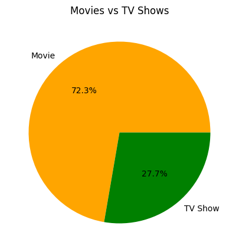

```python
mylabel = df_final['type'].value_counts()
label = mylabel.index
sizes = mylabel.values
plt.figure(figsize=(10,5))
plt.pie(sizes, labels=label, autopct='%1.1f%%', colors=['orange', 'green'])
plt.title('Movies vs TV Shows')
plt.show()
```

**Insight -**

- Movies make up 72.3% of the content, indicating a strong focus on feature films over TV shows.
- TV shows constitute only 27.7% of the content, highlighting an opportunity for growth in serialized content.

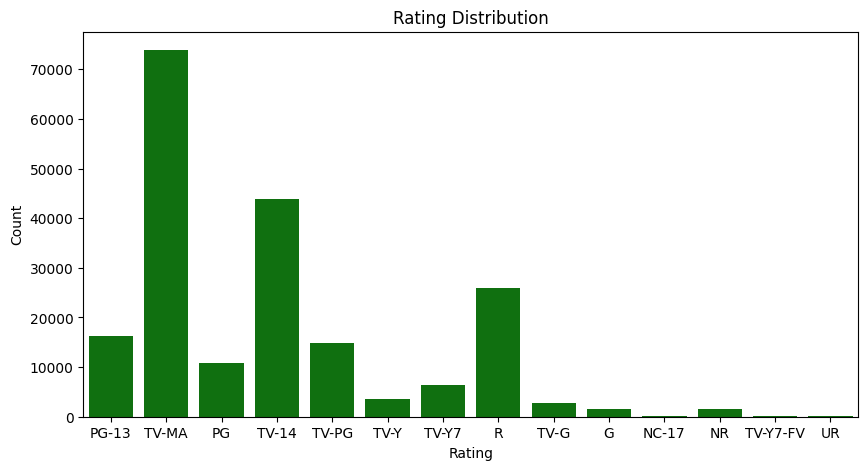

```python
#Rating count distribution
plt.figure(figsize=(10,5))
sns.countplot(data=df_final,x="rating",color="green")
plt.xlabel("Rating")
plt.ylabel("Count")
plt.title("Rating Distribution")
plt.show()
```

**Insight -**

- TV-MA content has the highest count, indicating strong viewer preference for mature-rated content.
- Ratings like TV-Y, TV-Y7, and G have significantly lower counts, suggesting less emphasis on family-friendly content.

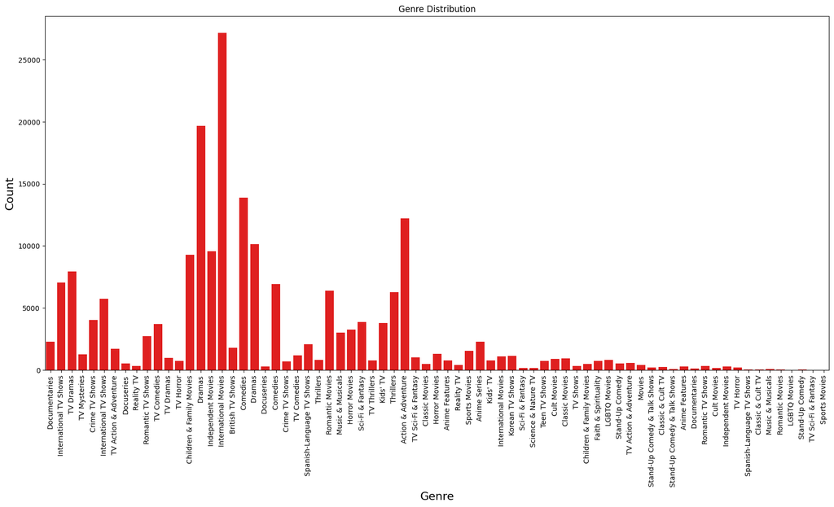

```python
#Different genres using countplot
fig = plt.figure(figsize = (20,20))
plt.subplot(2,1,1)
plt.xticks(rotation = 90)
sns.countplot(data = df_final, x = 'listed_in',color="red")
plt.xlabel("Genre",fontsize=16)
plt.ylabel("Count",fontsize=16)
plt.title("Genre Distribution")
plt.show()
```

**Insight -**

- Dramas, international TV shows, and children & family movies are among the most popular genres.
- Genres like science & nature TV, teen TV shows, and anime movies have lower counts, indicating potential areas for content expansion

```python
# getting top 10 directors
# dropping of the unknown rating to get better visualisation, and for that creating a deep copy of original dataframe
df_new= df_final.loc[df_final['director']!='Unknown Director']
df_new.groupby('director')['title'].nunique().sort_values(ascending  = False)[0:11].reset_index()
```

|  | director | title |
| --- | --- | --- |
| 0 | Rajiv Chilaka | 22 |
| 1 | Jan Suter | 18 |
| 2 | Raúl Campos | 18 |
| 3 | Suhas Kadav | 16 |
| 4 | Marcus Raboy | 16 |
| 5 | Jay Karas | 15 |
| 6 | Cathy Garcia-Molina | 13 |
| 7 | Jay Chapman | 12 |
| 8 | Martin Scorsese | 12 |
| 9 | Youssef Chahine | 12 |
| 10 | Steven Spielberg | 11 |

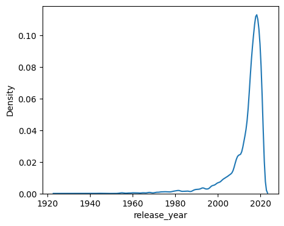

```python
# Movies and TV shows released trend analysis
plt.figure(figsize=(5,4))
sns.kdeplot(df_final['release_year'])
plt.show()
```

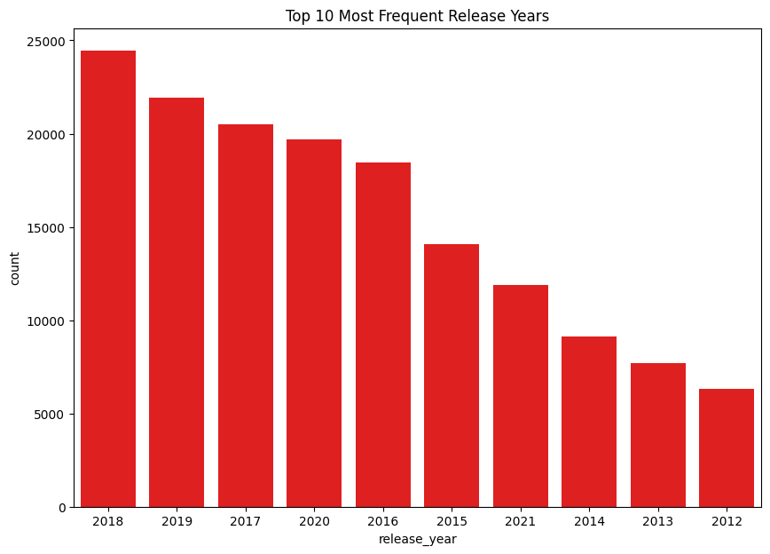

```python
#Count of Movies,TV Shows releases,which year has most releases on netflix
plt.figure(figsize=(10,7))
sns.countplot(data=df_final, x='release_year',order=df_final['release_year'].value_counts().head(10).index,color="red")
plt.title('Top 10 Most Frequent Release Years')
```

```python
df_final["country"]=df_final["country"].str.strip()
```

## **2. Comparison of TV Shows vs. Movies.**

### Find the number of movies produced in each country and pick the top 10 countries.

```python
#Movies count by Various Countries
df_co=df_final.loc[df_final["country"]!="Unknown Country"]
df_co[(df_co['type'] == 'Movie')]['country'].value_counts().head(11)
```

```
country
United States     45814
India             21411
United Kingdom     8580
France             6607
Canada             5738
Japan              3525
Spain              3469
Germany            3427
China              2377
Nigeria            2236
Hong Kong          2205
Name: count, dtype: int64
```

```python
#TV Shows count by Various Countries
df_co=df_final.loc[df_final["country"]!="Unknown Country"]
df_co[(df_co['type'] == 'TV Show')]['country'].value_counts().head(11)
```

```
country
United States     13449
Japan              5074
United Kingdom     4358
South Korea        3754
Canada             2177
Mexico             2018
Spain              1846
Taiwan             1719
France             1647
India              1403
Colombia           1284
Name: count, dtype: int64
```

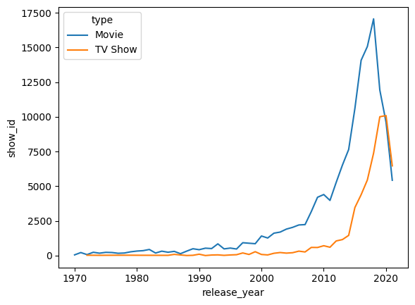

```python
#Movies Vs TV Shows release trend analysis
s = df_final.groupby(['release_year','type'])['show_id'].count()
s = s.reset_index()
s = s[s['release_year'] >= 1970]
sns.lineplot(data = s, x = 'release_year', y = 'show_id',hue='type')
plt.show()
```

# **3. What is the best time to launch a TV show?**

## a. Find which is the best week to release the Tv-show or the movie. Do the analysis separately for Tv-shows and Movies

```python
best_week = df_final.groupby('week_added')['type'].value_counts()
best_week
```

```
week_added  type
1           Movie      8456
            TV Show     938
2           Movie      1618
            TV Show     585
3           Movie      2031
                       ...
51          TV Show    1173
52          Movie      1840
            TV Show    1111
53          Movie      1413
            TV Show    1038
Name: count, Length: 106, dtype: int64
```

## b. Find which is the best month to release the Tv-show or the movie. Do the analysis separately for Tv-shows and Movies

```python
best_month = df_final.groupby('type')['month_added'].value_counts()
best_month
```

```
type     month_added
Movie    7.0            15075
         1.0            13945
         10.0           13541
         9.0            13219
         12.0           12768
         4.0            12537
         8.0            11923
         6.0            11616
         3.0            11500
         11.0           11065
         5.0             9579
         2.0             9137
TV Show  12.0            5297
         7.0             5129
         8.0             5029
         6.0             4959
         9.0             4818
         4.0             4460
         11.0            4428
         3.0             4201
         10.0            4199
         5.0             4111
         1.0             3941
         2.0             3772
Name: count, dtype: int64
```

# **4. Analysis of actors/directors of different types of shows/movies.**

## a. Identify the top 10 directors who have appeared in most movies or TV shows.

```python
top_actors = df_final[df_final['type'] == 'Movie']['cast'].value_counts()[1:11].reset_index()
top_actors
```

|  | cast | count |
| --- | --- | --- |
| 0 | Alfred Molina | 157 |
| 1 | Salma Hayek | 130 |
| 2 | Frank Langella | 128 |
| 3 | John Krasinski | 120 |
| 4 | Liam Neeson | 120 |
| 5 | John Rhys-Davies | 116 |
| 6 | Anupam Kher | 107 |
| 7 | Quvenzhané Wallis | 100 |
| 8 | Ben Whishaw | 86 |
| 9 | Jim Broadbent | 86 |

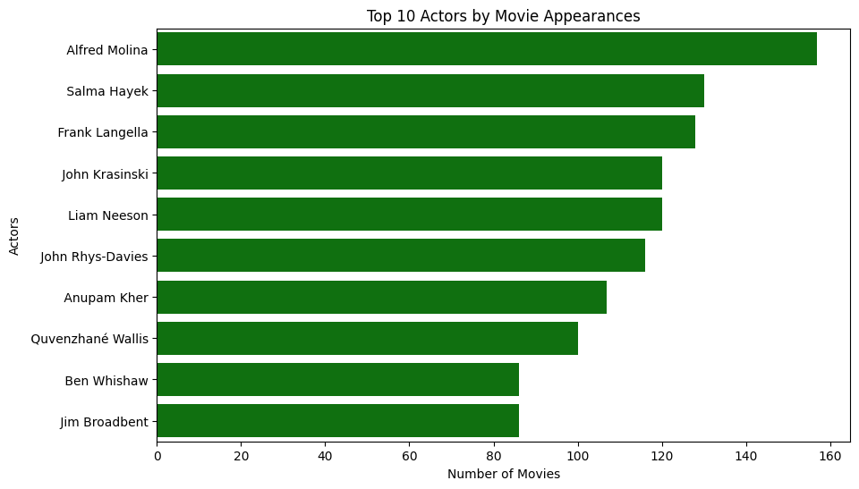

```python
plt.figure(figsize=(10, 6))
sns.barplot(x='count', y='cast', data=top_actors, color='green')
plt.title('Top 10 Actors by Movie Appearances')
plt.xlabel('Number of Movies')
plt.ylabel('Actors')
plt.show()
```

```python
df_new= df_final.loc[df_final['director']!='Unknown Director']
df_new.groupby('director')['title'].nunique().sort_values(ascending  = False)[0:11].reset_index()
```

|  | director | title |
| --- | --- | --- |
| 0 | Rajiv Chilaka | 22 |
| 1 | Jan Suter | 18 |
| 2 | Raúl Campos | 18 |
| 3 | Suhas Kadav | 16 |
| 4 | Marcus Raboy | 16 |
| 5 | Jay Karas | 15 |
| 6 | Cathy Garcia-Molina | 13 |
| 7 | Jay Chapman | 12 |
| 8 | Martin Scorsese | 12 |
| 9 | Youssef Chahine | 12 |
| 10 | Steven Spielberg | 11 |

# **5. Which genre movies are more popular or produced more**

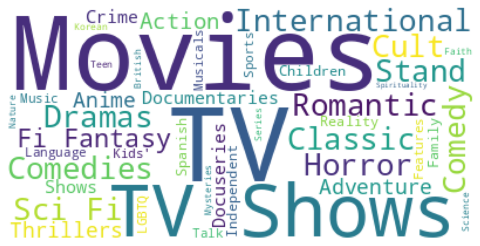

```python
a = df_final['listed_in'].unique()
from wordcloud import WordCloud
word = WordCloud(background_color  = 'white').generate(' '.join(a))
plt.figure(figsize = (10,8))
plt.imshow(word)
plt.axis("off")
plt.show()
```

**Insight -**

- The word cloud shows "Movies," "TV Shows," and "International" as dominant interests. For a balance of genres, try "Sci-Fi Thrillers" for excitement and "Comedies" for a lighter mood.

# **6. Find After how many days the movie will be added to Netflix after the release of the movie (you can consider the recent past data)**

```python
# calculating the difference of release year and date added
df_final['release_date'] = pd.to_datetime(df_final['release_year'].astype(str) + '-01-01')
df_final['date_added'] = pd.to_datetime(df_final['date_added'])
df_final['days_to_netflix'] = (df_final['date_added'] - df_final['release_date']).dt.days
```

```python
df_final.head()
```

|  | show_id | type | title | date_added | release_year | rating | duration | description | director | cast | country | listed_in | month_added | year_added | week_added | release_date | days_to_netflix |
| --- | --- | --- | --- | --- | --- | --- | --- | --- | --- | --- | --- | --- | --- | --- | --- | --- | --- |
| 0 | s1 | Movie | Dick Johnson Is Dead | 2021-09-25 | 2020 | PG-13 | 90 min | As her father nears the end of his life, filmm... | Kirsten Johnson | Unknown Actor | United States | Documentaries | 9.0 | 2021.0 | 38 | 2020-01-01 | 633.0 |
| 1 | s2 | TV Show | Blood & Water | 2021-09-24 | 2021 | TV-MA | 2 Seasons | After crossing paths at a party, a Cape Town t... | Unknown Director | Ama Qamata | South Africa | International TV Shows | 9.0 | 2021.0 | 38 | 2021-01-01 | 266.0 |
| 2 | s2 | TV Show | Blood & Water | 2021-09-24 | 2021 | TV-MA | 2 Seasons | After crossing paths at a party, a Cape Town t... | Unknown Director | Ama Qamata | South Africa | TV Dramas | 9.0 | 2021.0 | 38 | 2021-01-01 | 266.0 |
| 3 | s2 | TV Show | Blood & Water | 2021-09-24 | 2021 | TV-MA | 2 Seasons | After crossing paths at a party, a Cape Town t... | Unknown Director | Ama Qamata | South Africa | TV Mysteries | 9.0 | 2021.0 | 38 | 2021-01-01 | 266.0 |
| 4 | s2 | TV Show | Blood & Water | 2021-09-24 | 2021 | TV-MA | 2 Seasons | After crossing paths at a party, a Cape Town t... | Unknown Director | Khosi Ngema | South Africa | International TV Shows | 9.0 | 2021.0 | 38 | 2021-01-01 | 266.0 |

**Insight -**

- Negative days in this context occur when the date_added is earlier than the release_date. This means the movie was added to Netflix before it was officially released.